# Team X - Lab 2

MARSS models

Nicole, Mary, Tina

April 22, 2025

# Data

Our lab team looked at the Oregon Coast coho salmon ESU. We subset this data from the esa-salmon.rda into one matrix ‘coho’ that contained time series data for 21 sub-populatins within this ESU. We also created a reference matrix called ‘pop.groups’ that assigned the 21 sub-populations into five assumed groups.

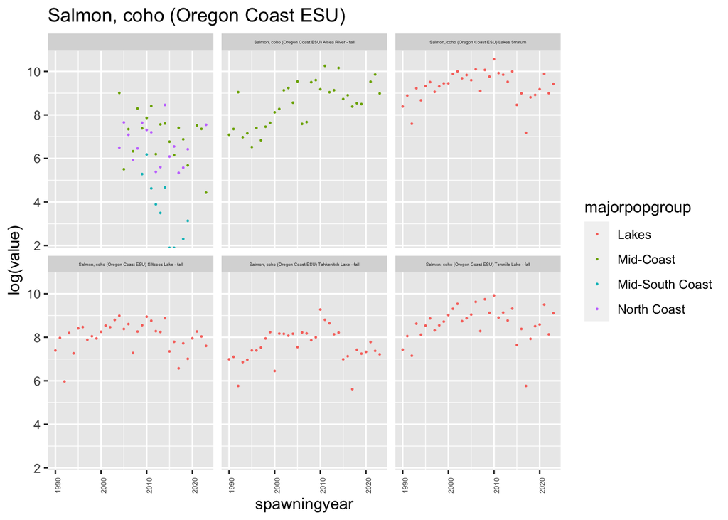

```
## [1] 21
```

# General Questions

1. Create estimates of spawner abundance for all missing years and provide estimates of the decline from the historical abundance.
2. Evaluate support for the major population groups. Are the populations in the groups more correlated than outside the groups?
3. Evaluate the evidence of cycling in the data. *We will talk about how to do this on the Tuesday after lab.*

# Methods

### Question 1

To create estimates of spawner abundance, we fit an unbiased random walk model using the MARSS function to create estimates of the “states” or x values. For this first model, we assumed R and Q are diagonal and equal, and U is equal to zero, thus no bias term will be included in this estimate. Below is a plot of sub-populations with the state estimates and observed spawner abundances.

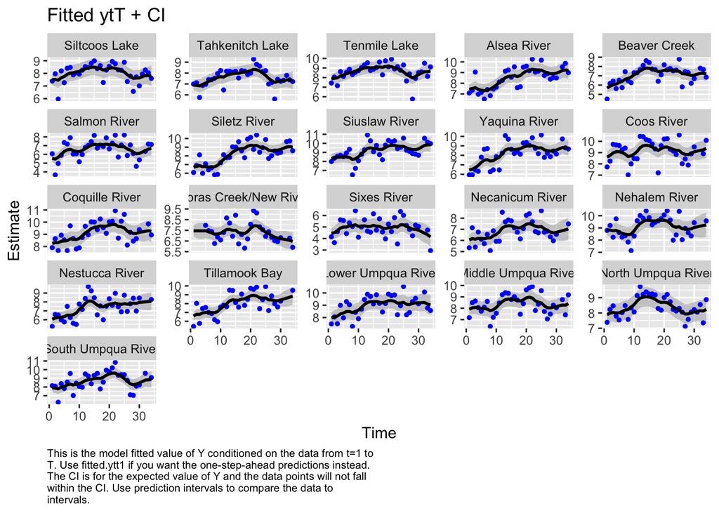

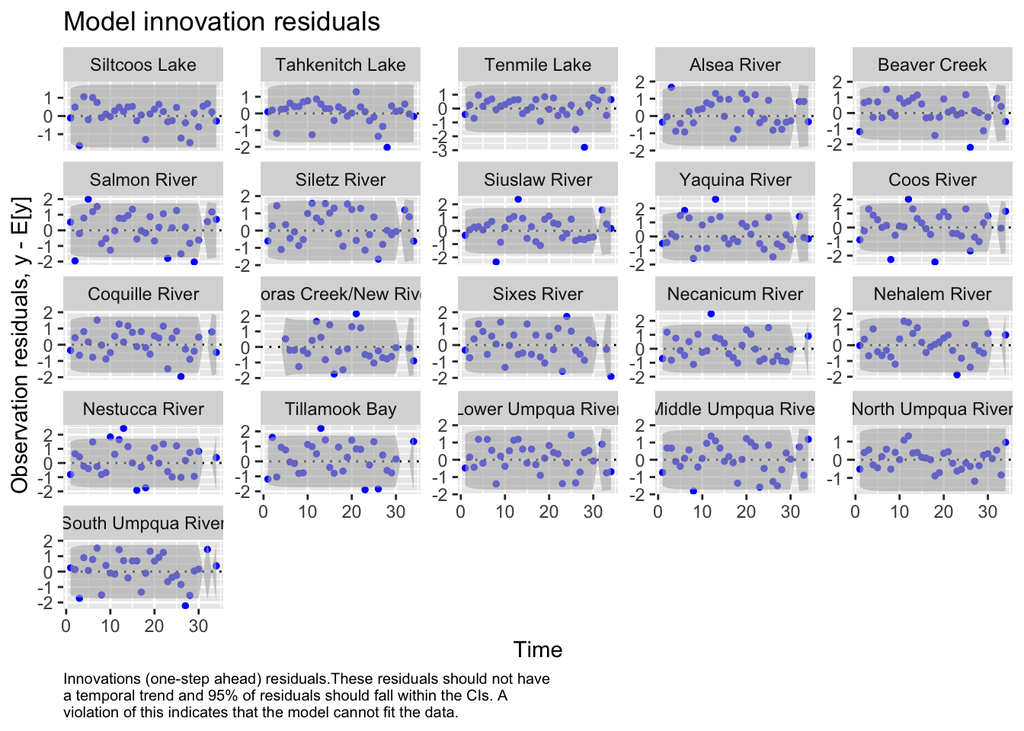

```
## plot.type = model.resids.ytt1
```

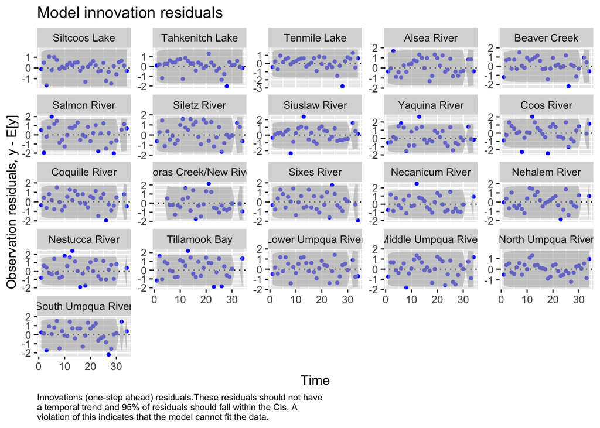

```
## Hit <Return> to see next plot (q to exit):
```

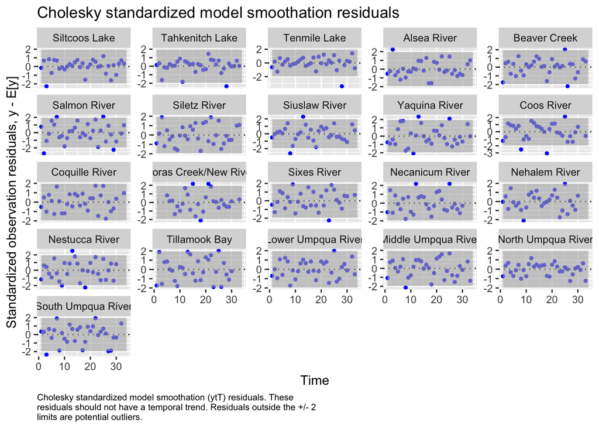

```
## plot.type = std.model.resids.ytT
```

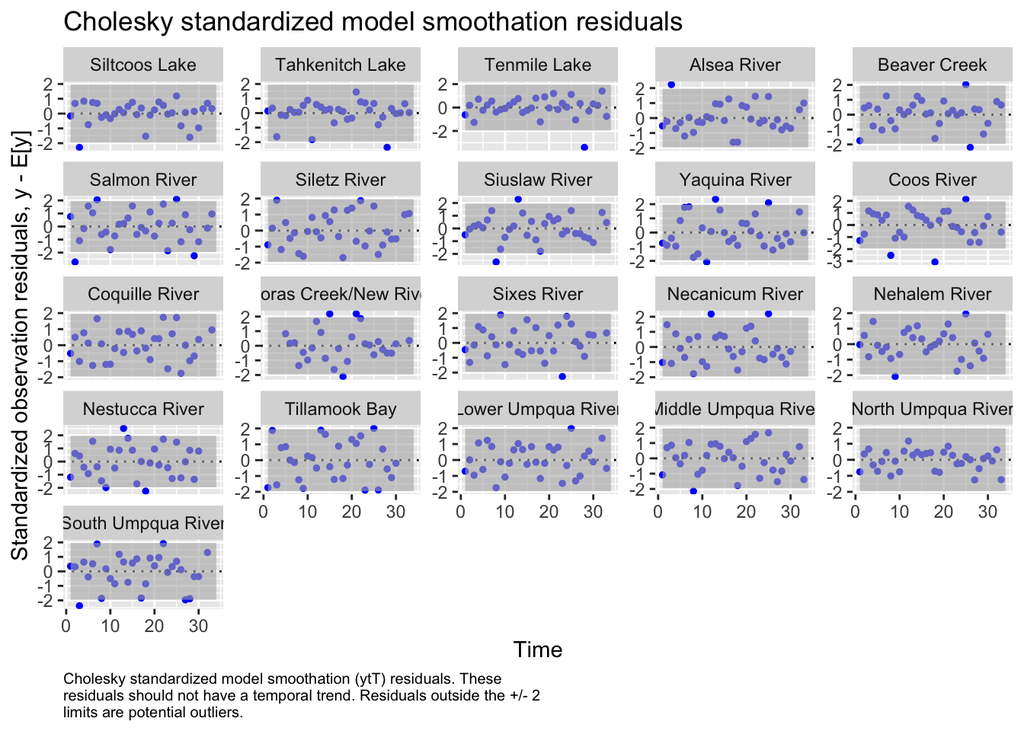

```
## Hit <Return> to see next plot (q to exit):
```

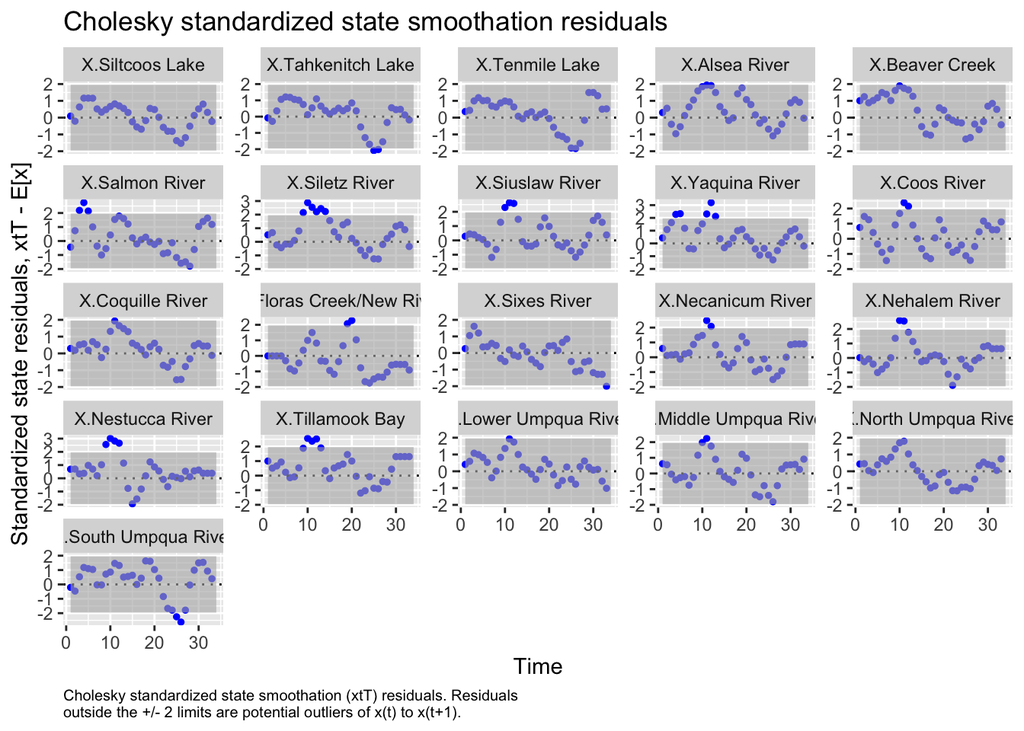

```
## plot.type = std.state.resids.xtT
```

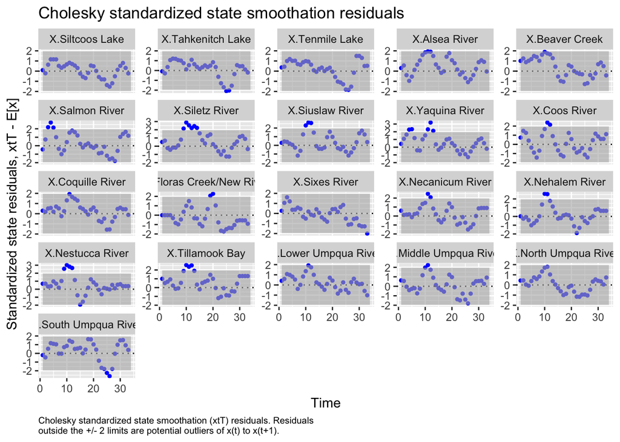

```
## Hit <Return> to see next plot (q to exit):
```

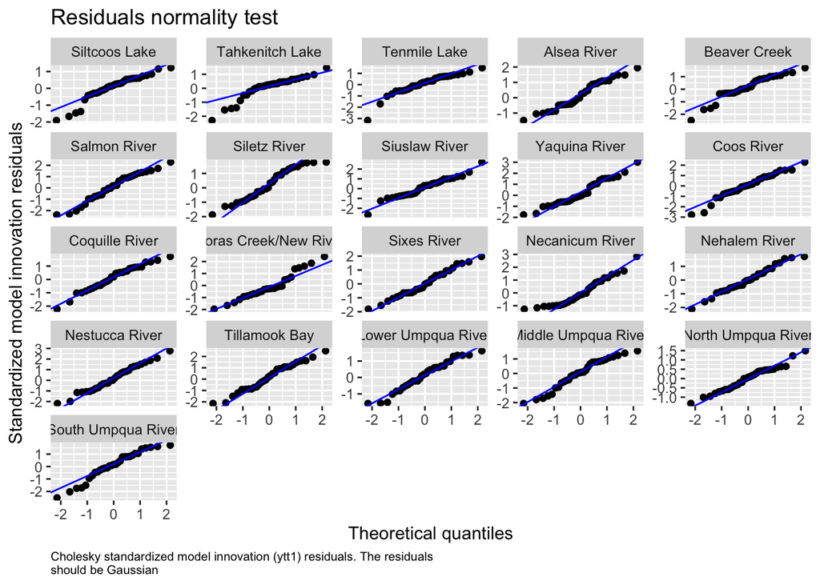

```
## plot.type = qqplot.std.model.resids.ytt1
```

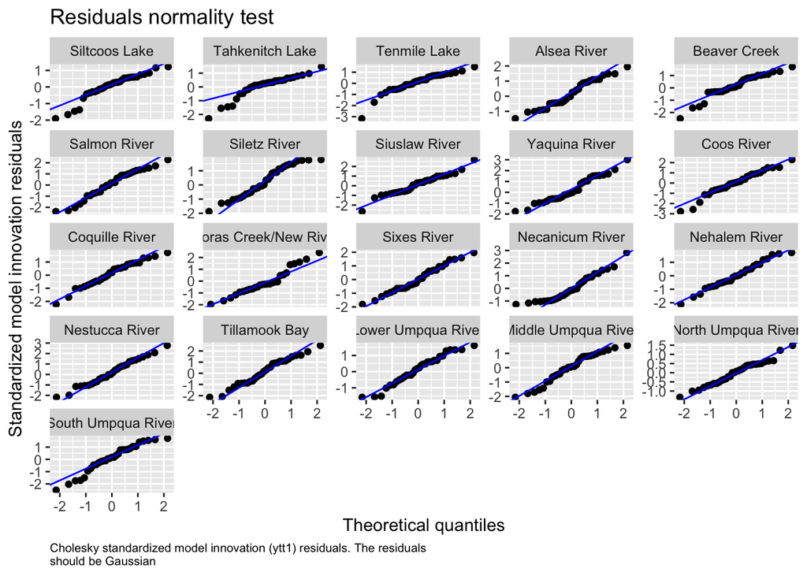